# Practice 03: Control Structures, Functions and Database Access

Software for Data Analysis, Lab 02: Programming in R

Marcos Cunchillos Just

2026-11-09

# Overview

This practice covers the core programming constructs of R (conditionals, loops and user-defined functions) applied to small biomedical problems, followed by SQL-based data access.

| Block | Topic | Skills practiced |
| --- | --- | --- |
| Exercises 1, 2 | Clinical data frame and reference tables | `dplyr` filtering, descriptive statistics, nested conditionals |
| Exercises 3-4, 6-7 | `anorexia` and `birthwt` (package `MASS`) | Frequency tables, loops with counters, vector building |
| Exercise 5 | Medical record constructor | Functions returning data frames |
| Exercise 8 | `Melanoma` survival data | Functions that traverse a data frame and return named vectors |
| Exercise 9 | `airquality` | SQL queries on a data frame with `sqldf` |
| Case 1 | Fibonacci series and the DNA double helix | Iterative sequences, ratios and the golden ratio |
| Case 2 | DNA sequences | String handling, reverse and complementary strands |
| Case 3 | Hospital database | `DBI` + `SQLite`, `JOIN`, aggregation, `ggplot2` |

```r
# MASS is loaded first so that dplyr::select() is not masked by MASS::select()
library(MASS)
library(dplyr)
library(DBI)
library(RSQLite)
library(sqldf)
library(ggplot2)
```

# Exercise 1. Patient data frame

> From the data of the hospital patients below, create a data frame and (1) filter the patients with cholesterol levels above 200, (2) compute descriptive statistics of the cholesterol levels.
> - **Patient1**: 45 years, Female, blood pressure 120/80, cholesterol 180
> - **Patient2**: 32 years, Male, blood pressure 130/85, cholesterol 200
> - **Patient3**: 28 years, Female, blood pressure 110/70, cholesterol 150
> - **Patient4**: 55 years, Male, blood pressure 140/90, cholesterol 220
> - **Patient5**: 40 years, Female, blood pressure 125/75, cholesterol 190

```r
patients <- data.frame(
  name           = c("Patient1", "Patient2", "Patient3", "Patient4", "Patient5"),
  age            = c(45, 32, 28, 55, 40),
  gender         = c("Female", "Male", "Female", "Male", "Female"),
  blood_pressure = c("120/80", "130/85", "110/70", "140/90", "125/75"),
  cholesterol    = c(180, 200, 150, 220, 190)
)

# Patients with cholesterol above 200 mg/dl
high_cholesterol <- patients %>%
  filter(cholesterol > 200)
high_cholesterol
```

| name | age | gender | blood_pressure | cholesterol |
| --- | --- | --- | --- | --- |
| Patient4 | 55 | Male | 140/90 | 220 |

```r
# Descriptive statistics of cholesterol
cholesterol_stats <- patients %>%
  summarise(
    mean_cholesterol   = mean(cholesterol),
    median_cholesterol = median(cholesterol),
    max_cholesterol    = max(cholesterol),
    min_cholesterol    = min(cholesterol),
    sd_cholesterol     = sd(cholesterol)
  )
cholesterol_stats
```

| mean_cholesterol | median_cholesterol | max_cholesterol | min_cholesterol | sd_cholesterol |
| --- | --- | --- | --- | --- |
| 188 | 190 | 220 | 150 | 25.88436 |

Only Patient4 (220 mg/dl) exceeds the threshold; Patient2 is exactly at 200 and is excluded by the strict inequality.

# Exercise 2. Optimal body fat percentage

> The optimal body fat percentage of an individual depends on age and gender. The reference values are:

> | Age (years) | Female (%) | Male (%) |
> | --- | --- | --- |
> | **10-30** | 20-26 | 12-18 |
> | **31-40** | 21-27 | 13-19 |
> | **41-50** | 22-28 | 14-20 |
> | **51-60** | 22-30 | 16-20 |
> | **61 or more** | 22-31 | 17-21 |

> *Note:* these values may vary slightly depending on the source (Nutrición y Multinivel).

> Define variables that represent the age and gender of an individual and, depending on the values assigned, show the optimal body fat percentage given by the table above.

```r
#' Show the optimal body fat percentage for an age and a gender
#'
#' Looks the individual up in the reference table with nested conditionals:
#' gender first, then age range.
#'
#' @param age Numeric. Age in years (the table starts at 10).
#' @param gender Character. Either "Female" or "Male".
#' @return Nothing. The recommended range is printed to the console.
optimal_body_fat <- function(age, gender) {
  if (age < 10) {
    cat("Age outside the range of the table (minimum 10 years)\n")
  } else if (gender == "Female") {
    if (age <= 30) {
      cat("Optimal body fat = 20-26 %\n")
    } else if (age <= 40) {
      cat("Optimal body fat = 21-27 %\n")
    } else if (age <= 50) {
      cat("Optimal body fat = 22-28 %\n")
    } else if (age <= 60) {
      cat("Optimal body fat = 22-30 %\n")
    } else {
      cat("Optimal body fat = 22-31 %\n")
    }
  } else if (gender == "Male") {
    if (age <= 30) {
      cat("Optimal body fat = 12-18 %\n")
    } else if (age <= 40) {
      cat("Optimal body fat = 13-19 %\n")
    } else if (age <= 50) {
      cat("Optimal body fat = 14-20 %\n")
    } else if (age <= 60) {
      cat("Optimal body fat = 16-20 %\n")
    } else {
      cat("Optimal body fat = 17-21 %\n")
    }
  } else {
    cat("Invalid gender: use \"Female\" or \"Male\"\n")
  }
}

# Variables of one individual
age <- 35
gender <- "Female"

optimal_body_fat(age, gender)
```

```
## Optimal body fat = 21-27 %
```

Because the conditions are evaluated in order, each branch only needs its upper age limit. The final `else` of each gender block covers everyone above 60, including non-integer ages such as 60.5.

# Exercise 3. Treatment distribution in `anorexia`

> From the `anorexia` data set of the `MASS` package, compute the percentage of patients who received each type of treatment.

```r
data("anorexia", package = "MASS")

treatment_table <- table(anorexia$Treat)
treatment_percentage <- prop.table(treatment_table)

round(treatment_percentage, 2) * 100
```

```
##
##  CBT Cont   FT
##   40   36   24
```

Of the 72 young women, 40% received cognitive behavioural therapy (CBT), 36% were in the control group (Cont) and 24% received family therapy (FT).

# Exercise 4. Low birth weight, young smoking mothers

> From the `birthwt` data set of the `MASS` package, compute how many newborns weighing less than 2,600 grams correspond to mothers younger than twenty who smoke.

```r
data("birthwt", package = "MASS")

# Vectorised approach
low_weight_infants <- birthwt %>%
  filter(bwt < 2600 & age < 20 & smoke == 1)
nrow(low_weight_infants)
```

```
## [1] 7
```

The same result with an explicit loop over the records:

```r
infant_count <- 0

for (i in 1:nrow(birthwt)) {
  if (birthwt$bwt[i] < 2600) {
    if (birthwt$age[i] < 20) {
      if (birthwt$smoke[i] == 1) {
        infant_count <- infant_count + 1
      }
    }
  }
}

print(infant_count)
```

```
## [1] 7
```

Both approaches give 7 newborns. Note that the loop must iterate over `nrow(birthwt)`: `length()` of a data frame returns the number of columns, not rows.

# Exercise 5. Medical record constructor

> Suppose we want to generate a medical record of patients with name, age, diagnosis and blood glucose level, using the data below. Define a function called `create_medical_record` that takes the four vectors as arguments (names, ages, diagnoses and glucose) and creates a data frame representing the patient medical record. The output must be a data frame with detailed information about each patient.

```r
patient_names <- c("Ana", "Luis", "Maria", "Carlos", "Elena")
ages          <- c(45, 32, 28, 55, 40)
diagnoses     <- c("Diabetes", "Hypertension", "Healthy", "Hypertension", "Asthma")
glucose       <- c(125, 140, 95, 160, 110)

#' Build a medical record data frame
#'
#' @param patient_names Character vector with the patient names.
#' @param ages Numeric vector with the patient ages (years).
#' @param diagnoses Character vector with the diagnoses.
#' @param glucose Numeric vector with blood glucose levels (mg/dl).
#' @return A data frame with one row per patient and the columns
#'   Name, Age, Diagnosis and Glucose.
create_medical_record <- function(patient_names, ages, diagnoses, glucose) {
  medical_record <- data.frame(
    Name      = patient_names,
    Age       = ages,
    Diagnosis = diagnoses,
    Glucose   = glucose
  )
  return(medical_record)
}

medical_record <- create_medical_record(patient_names, ages, diagnoses, glucose)
print(medical_record)
```

```
##     Name Age    Diagnosis Glucose
## 1    Ana  45     Diabetes     125
## 2   Luis  32 Hypertension     140
## 3  Maria  28      Healthy      95
## 4 Carlos  55 Hypertension     160
## 5  Elena  40       Asthma     110
```

# Exercise 6. Birth weights of babies born to young mothers

> From the `birthwt` data set, store in a vector the weights of the newborns whose mothers are younger than 20 years. Compute the mean and plot this vector (for example, a dot plot).

```r
young_mothers_weights <- c()
j <- 1

# Loop that stores the weights
for (i in 1:nrow(birthwt)) {
  if (birthwt$age[i] < 20) {
    young_mothers_weights[j] <- birthwt$bwt[i]
    j <- j + 1
  }
}

# Mean birth weight
mean(young_mothers_weights)
```

```
## [1] 2973.529
```

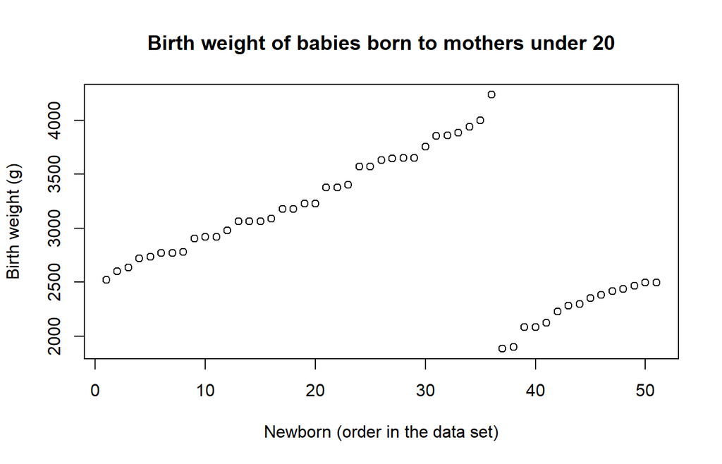

```r
# Dot plot
plot(young_mothers_weights,
     xlab = "Newborn (order in the data set)",
     ylab = "Birth weight (g)",
     main = "Birth weight of babies born to mothers under 20")
```

# Exercise 7. White mothers and below-average birth weight

> From the `birthwt` data set, create a function that shows the weights of the newborns whose mothers are white and whose weight is below the mean of the observed weights.

```r
#' Birth weights below the sample mean for babies of white mothers
#'
#' Both conditions are evaluated in a single filter, so the mean is computed
#' over all newborns (as the statement requires) and not only over white mothers.
#'
#' @param data A data frame with the columns `race` (1 = white) and `bwt` (grams).
#' @return A numeric vector with the selected birth weights.
low_weights_white_mothers <- function(data) {
  weights <- data %>%
    filter(race == 1 & bwt < mean(bwt)) %>%
    pull(bwt)
  return(weights)
}

low_weights_white_mothers(birthwt)
```

```
##  [1] 2557 2594 2600 2637 2663 2665 2769 2769 2782 2821 2835 2836 2877 2906 2920
## [16] 2922 1021 1790 1818 1885 1928 1928 1936 2082 2084 2084 2100 2187 2225 2296
## [31] 2353 2353 2410 2410 2414 2424 2466 2466 2495
```

The function returns 39 weights. Filtering by race first and then by the mean would have computed the mean over white mothers only, giving a different result (52 values).

# Exercise 8. Melanoma survival data

> From the `Melanoma` data set of the `MASS` package (survival data of malignant melanoma), solve the following questions.

## 8a. Ages

> Define a vector that stores the ages of the observed individuals and compute the mean, maximum and minimum of this distribution.

```r
data("Melanoma", package = "MASS")

ages <- c()

for (i in 1:nrow(Melanoma)) {
  ages[i] <- Melanoma$age[i]
}

cat("Maximum age = ", max(ages), "\n")
```

```
## Maximum age =  95
```

```r
cat("Minimum age = ", min(ages), "\n")
```

```
## Minimum age =  4
```

```r
cat("Mean age    = ", mean(ages), "\n")
```

```
## Mean age    =  52.46341
```

## 8b. Outcomes

> Define a function that traverses the data set and shows how many individuals died from melanoma, how many survived and how many died from other causes.

```r
#' Count the outcomes of the Melanoma data set
#'
#' @param data A data frame with a `status` column coded as
#'   1 = died from melanoma, 2 = alive, 3 = died from other causes.
#' @return A named numeric vector with the three counts.
count_melanoma_outcomes <- function(data) {
  melanoma_deaths <- 0
  survivors <- 0
  other_causes <- 0

  for (i in 1:nrow(data)) {
    if (data$status[i] == 1) {
      melanoma_deaths <- melanoma_deaths + 1
    } else if (data$status[i] == 2) {
      survivors <- survivors + 1
    } else if (data$status[i] == 3) {
      other_causes <- other_causes + 1
    }
  }

  return(c(
    melanoma_deaths = melanoma_deaths,
    survivors       = survivors,
    other_causes    = other_causes
  ))
}

count_melanoma_outcomes(Melanoma)
```

```
## melanoma_deaths       survivors    other_causes
##              57             134              14
```

Of the 205 patients, 57 died from melanoma, 134 survived and 14 died from other causes.

## 8c. Sex distribution of melanoma deaths

> Define a function that traverses the data set and shows the proportion of men and women who died from melanoma.

```r
#' Proportion of men and women among melanoma deaths
#'
#' @param data A data frame with `status` (1 = died from melanoma) and
#'   `sex` (1 = male, 0 = female).
#' @return A named numeric vector with the proportion of men and women.
melanoma_deaths_by_sex <- function(data) {
  men <- 0
  women <- 0
  deaths <- 0

  for (i in 1:nrow(data)) {
    if (data$status[i] == 1) {
      deaths <- deaths + 1
      if (data$sex[i] == 1) {
        men <- men + 1
      } else {
        women <- women + 1
      }
    }
  }

  # Proportions are computed once, after the loop has counted every record
  return(c(
    proportion_men   = men / deaths,
    proportion_women = women / deaths
  ))
}

melanoma_deaths_by_sex(Melanoma)
```

```
##   proportion_men proportion_women
##        0.5087719        0.4912281
```

Among the 57 melanoma deaths, 29 were men (50.9%) and 28 were women (49.1%): the two sexes are almost equally represented.

# Exercise 9. SQL queries on `airquality`

> From the `airquality` data set, solve the following queries.

**1) Show the mean of Ozone.**

```r
data("airquality")
sqldf("SELECT AVG(Ozone) FROM airquality")
```

| AVG(Ozone) |
| --- |
| 42.12931 |

`AVG()` ignores `NULL` values, so the missing ozone measurements are excluded automatically.

**2) Show Ozone, Solar.R and Wind for months 5, 6 and 7.**

```r
sqldf("SELECT Ozone, [Solar.R], Wind FROM airquality WHERE Month IN (5, 6, 7)")
```

| Ozone | Solar.R | Wind |
| --- | --- | --- |
| 41 | 190 | 7.4 |
| 36 | 118 | 8.0 |
| 12 | 149 | 12.6 |
| 18 | 313 | 11.5 |
| NA | NA | 14.3 |
| 28 | NA | 14.9 |
| 23 | 299 | 8.6 |
| 19 | 99 | 13.8 |
| 8 | 19 | 20.1 |
| NA | 194 | 8.6 |

[output cut: 82 more lines]

**3) Show the previous information ordered by Month.**

```r
sqldf("SELECT Month, Ozone, [Solar.R], Wind FROM airquality
       WHERE Month IN (5, 6, 7) ORDER BY Month")
```

| Month | Ozone | Solar.R | Wind |
| --- | --- | --- | --- |
| 5 | 41 | 190 | 7.4 |
| 5 | 36 | 118 | 8.0 |
| 5 | 12 | 149 | 12.6 |
| 5 | 18 | 313 | 11.5 |
| 5 | NA | NA | 14.3 |
| 5 | 28 | NA | 14.9 |
| 5 | 23 | 299 | 8.6 |
| 5 | 19 | 99 | 13.8 |
| 5 | 8 | 19 | 20.1 |
| 5 | NA | 194 | 8.6 |

[output cut: 82 more lines]

**4) Show Wind grouped by Month, displaying only the first five records.**

```r
sqldf("SELECT Wind, Month FROM airquality GROUP BY Month LIMIT 5")
```

| Wind | Month |
| --- | --- |
| 7.4 | 5 |
| 8.6 | 6 |
| 4.1 | 7 |
| 6.9 | 8 |
| 6.9 | 9 |

`GROUP BY Month` returns one row per month. Since `Wind` is not aggregated, SQLite shows an arbitrary value of each group; to summarise it meaningfully one would use an aggregate such as `AVG(Wind)`.

# Case Study 1. The Fibonacci series in DNA molecules

> According to Mark E. Curtis, each complete turn of the DNA double helix measures 21 Å wide by 34 Å long; 34 and 21 are two consecutive numbers of the Fibonacci sequence. Their quotient, 1.6190476, closely approximates the golden ratio φ = 1.6180339…

## a) Fibonacci series

> Implement a function that, given a value n, shows the values of the Fibonacci series up to that value.

```r
#' Generate the first n terms of the Fibonacci series
#'
#' Each term is the sum of the two previous ones, starting at 0 and 1.
#'
#' @param n Integer. Number of terms to generate.
#' @return A numeric vector with the first n terms.
fibonacci_series <- function(n) {
  terms <- c(0, 1)

  # For n <= 2 the first terms are already available
  if (n <= 2) {
    return(terms[1:n])
  }

  for (i in 2:(n - 1)) {
    terms[i + 1] <- terms[i] + terms[i - 1]
  }
  return(terms)
}

fibonacci_series(5)
```

```
## [1] 0 1 1 2 3
```

## b) Where are the DNA measurements in the series?

> For which values of n do we find the measurements of the DNA double helix in the Fibonacci series?

```r
fibonacci_series(9)
```

```
## [1]  0  1  1  2  3  5  8 13 21
```

```r
fibonacci_series(10)
```

```
##  [1]  0  1  1  2  3  5  8 13 21 34
```

The width of the helix (21 Å) is the 9th term of the series and the length (34 Å) is the 10th, so both appear when n = 10.

## c) Successive ratios

> Extend the code so that, for a given n, it shows the successive ratios of the Fibonacci terms. From which value of n does this ratio approach the golden ratio?

```r
#' Fibonacci terms together with the ratio to the previous term
#'
#' @param n Integer. Number of terms (at least 3).
#' @return A data frame with the Fibonacci terms and the ratio of each term to
#'   the previous one. The first two rows have no ratio (`NA`).
fibonacci_ratios <- function(n) {
  terms <- c(0, 1)
  ratios <- c()

  for (i in 2:(n - 1)) {
    terms[i + 1] <- terms[i] + terms[i - 1]
    ratios[i + 1] <- terms[i + 1] / terms[i]
  }
  return(data.frame(term = terms, ratio = ratios))
}

# 15 terms are enough to see the convergence
fibonacci_ratios(15)
```

| term | ratio |
| --- | --- |
| 0 | NA |
| 1 | NA |
| 1 | 1.000000 |
| 2 | 2.000000 |
| 3 | 1.500000 |
| 5 | 1.666667 |
| 8 | 1.600000 |
| 13 | 1.625000 |
| 21 | 1.615385 |
| 34 | 1.619048 |

[output cut: 5 more lines]

```r
# Golden ratio for reference
(1 + sqrt(5)) / 2
```

```
## [1] 1.618034
```

# Case Study 2. DNA sequences

> Generate a DNA sequence and compute its reverse and its complementary strand.

```r
#' Generate a random DNA sequence
#'
#' @param n Integer. Length of the sequence.
#' @return A character string made of the bases A, C, G and T.
generate_sequence <- function(n) {
  bases <- c("C", "A", "T", "G")
  sequence <- sample(bases, n, replace = TRUE)
  return(paste(sequence, collapse = ""))
}

#' Reverse a DNA sequence
#'
#' @param sequence Character string with the DNA sequence.
#' @return The sequence read from the last base to the first.
reverse_sequence <- function(sequence) {
  reversed <- rev(strsplit(sequence, "")[[1]])
  return(paste(reversed, collapse = ""))
}

#' Complementary strand of a DNA sequence
#'
#' Pairs each base with its Watson-Crick partner (A-T, G-C), keeping the
#' original order.
#'
#' @param sequence Character string with the DNA sequence.
#' @return A character string with the complementary bases.
complementary_sequence <- function(sequence) {
  bases <- strsplit(sequence, "")[[1]]
  complement <- c()

  for (i in 1:length(bases)) {
    if (bases[i] == "A") {
      complement[i] <- "T"
    } else if (bases[i] == "T") {
      complement[i] <- "A"
    } else if (bases[i] == "G") {
      complement[i] <- "C"
    } else {
      complement[i] <- "G"
    }
  }
  return(paste(complement, collapse = ""))
}

set.seed(123)  # reproducible random sequence

original_sequence <- generate_sequence(20)
reversed_sequence <- reverse_sequence(original_sequence)
complement_sequence <- complementary_sequence(original_sequence)

cat("Original sequence:      ", original_sequence, "\n")
```

```
## Original sequence:       TTTATAAATCGAACATGCTT
```

```r
cat("Reversed sequence:      ", reversed_sequence, "\n")
```

```
## Reversed sequence:       TTCGTACAAGCTAAATATTT
```

```r
cat("Complementary sequence: ", complement_sequence, "\n")
```

```
## Complementary sequence:  AAATATTTAGCTTGTACGAA
```

# Case Study 3. Hospital patient database

> Suppose we want to manage the information of a hospital patient database with two tables, `patients` (name, age, gender, medical_condition) and `medical_records` (patient_id, date, glucose_level), with the records given in the statement. Use database access instructions to solve the following questions.

## 1) Create the database, tables and connection

```r
# SQLite file database; extended_types keeps R dates as dates
con <- dbConnect(SQLite(), "hospital.db", extended_types = TRUE)

patients <- data.frame(
  patient_id        = 1:5,
  name              = c("Patient1", "Patient2", "Patient3", "Patient4", "Patient5"),
  age               = c(45, 32, 28, 55, 40),
  gender            = c("Female", "Male", "Female", "Male", "Female"),
  medical_condition = c("Diabetes", "Hypertension", "Healthy", "Hypertension", "Asthma")
)
dbWriteTable(con, "patients", patients, row.names = FALSE, overwrite = TRUE)

medical_records <- data.frame(
  patient_id    = 1:5,
  date          = as.Date("2023-08-01"),
  glucose_level = c(125.5, 140.2, 95.8, 160.6, 110.9)
)
dbWriteTable(con, "medical_records", medical_records, row.names = FALSE, overwrite = TRUE)

dbListTables(con)
```

```
## [1] "medical_records"   "pacientes"         "patients"
## [4] "registros_médicos"
```

The `patient_id` column is the key that links both tables: it is added to `patients` because the records refer to patients by their order (1 to 5).

## 2) Patients with a specific medical condition

```r
dbGetQuery(con, "SELECT * FROM patients WHERE medical_condition = 'Diabetes'")
```

| patient_id | name | age | gender | medical_condition |
| --- | --- | --- | --- | --- |
| 1 | Patient1 | 45 | Female | Diabetes |

## 3) Descriptive statistics of blood glucose

```r
glucose_levels <- dbGetQuery(con, "SELECT glucose_level FROM medical_records")$glucose_level

cat("Mean               =", mean(glucose_levels), "\n")
```

```
## Mean               = 126.6
```

```r
cat("Median             =", median(glucose_levels), "\n")
```

```
## Median             = 125.5
```

```r
cat("Standard deviation =", sd(glucose_levels), "\n")
```

```
## Standard deviation = 25.18581
```

```r
cat("Minimum            =", min(glucose_levels), "\n")
```

```
## Minimum            = 95.8
```

```r
cat("Maximum            =", max(glucose_levels), "\n")
```

```
## Maximum            = 160.6
```

## 4) Medical records of patients with hypertension and their glucose statistics

```r
hypertension_records <- dbGetQuery(con, "
  SELECT p.name, r.date, r.glucose_level
  FROM patients p
  JOIN medical_records r ON p.patient_id = r.patient_id
  WHERE p.medical_condition = 'Hypertension'")
hypertension_records
```

| name | date | glucose_level |
| --- | --- | --- |
| Patient2 | 2023-08-01 | 140.2 |
| Patient4 | 2023-08-01 | 160.6 |

```r
dbGetQuery(con, "
  SELECT AVG(r.glucose_level) AS mean_glucose,
         MAX(r.glucose_level) AS max_glucose,
         MIN(r.glucose_level) AS min_glucose
  FROM patients p
  JOIN medical_records r ON p.patient_id = r.patient_id
  WHERE p.medical_condition = 'Hypertension'")
```

| mean_glucose | max_glucose | min_glucose |
| --- | --- | --- |
| 150.4 | 160.6 | 140.2 |

Joining on `patient_id` links each record to the right patient regardless of row order, which makes it safer than binding the two tables column-wise.

## 5) Mean age of asthma patients by gender

```r
dbGetQuery(con, "
  SELECT gender, AVG(age) AS mean_age
  FROM patients
  WHERE medical_condition = 'Asthma'
  GROUP BY gender")
```

| gender | mean_age |
| --- | --- |
| Female | 40 |

Only one patient has asthma (a 40-year-old woman), so the mean age equals her age and no male group appears.

## 6) Gender distribution of patients with diabetes

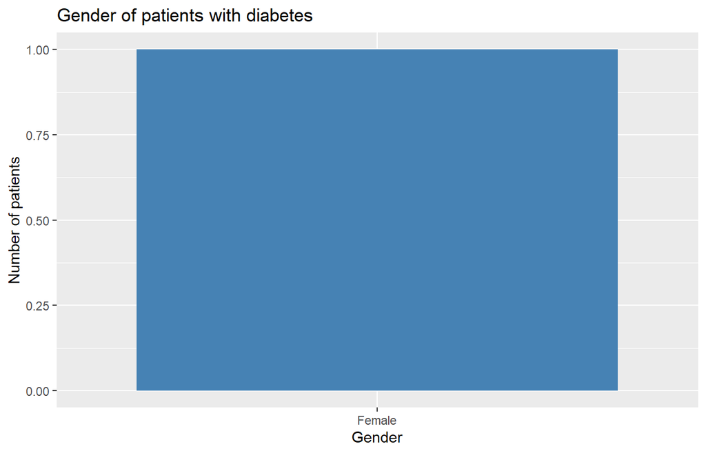

```r
diabetes_gender <- dbGetQuery(con, "SELECT * FROM patients WHERE medical_condition = 'Diabetes'")

ggplot(diabetes_gender, aes(x = gender)) +
  geom_bar(fill = "steelblue") +
  labs(title = "Gender of patients with diabetes",
       x = "Gender", y = "Number of patients")
```

```r
dbDisconnect(con)
```

`geom_bar()` counts the rows of each category by itself; with a single diabetic patient the chart shows one bar (Female).